An Introduction to oTree Style Matteo Ploner (UNITN)

# Style

## Appearance of pages

- You can control the appearance of pages (templates) with style files
  - [HTML tags](https://www.w3schools.com/html/default.asp)
  - [CSS files](https://www.w3schools.com/css/default.asp)
    - Colors, fonts, spaces, borders

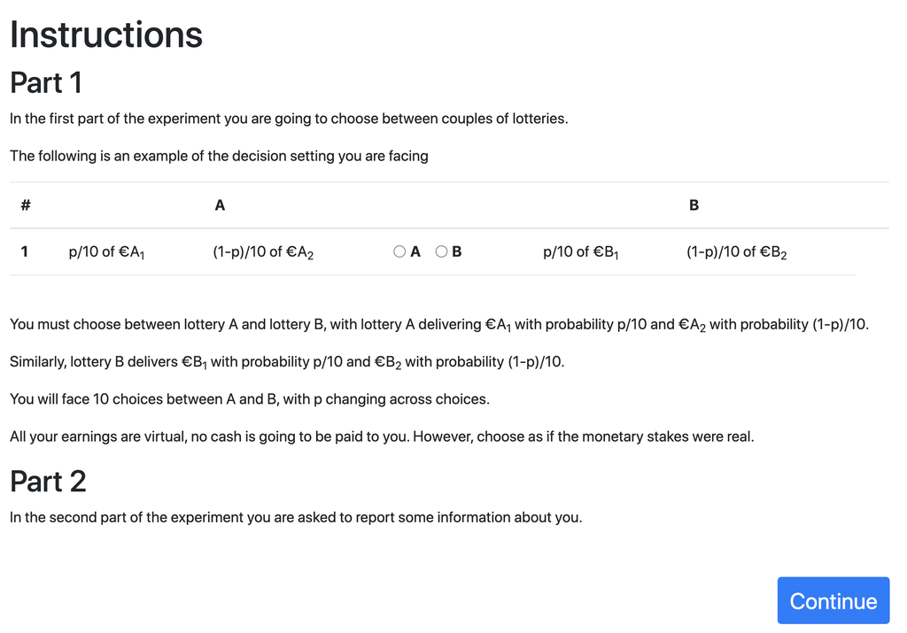

→

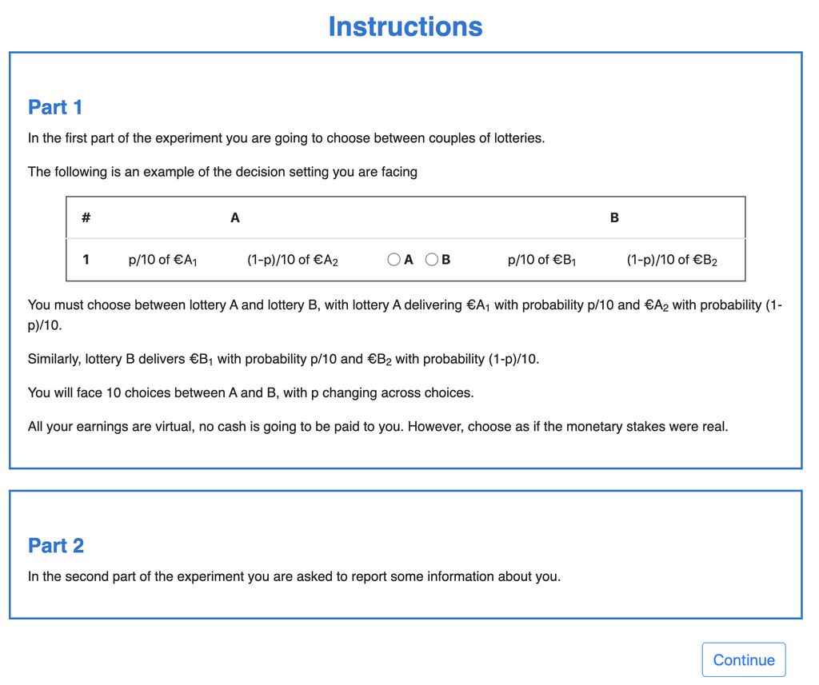

## HTML tags: Headings and paragaphs

```html
<h1>Instructions</h1>

  <h2> Part 1 </h2>

      <p>In the first part of the experiment you are going to choose between couples of lotteries. </p>

[...]
```

- **Headings** (titles subtitles)
  - Highlight the headings with tags `<h#> </h#>
    - Hyerarchical structure
      - `<h1> Section</h1>`
        - `<h2> Subsection </h2>`
          - `<h3> Subsubsection </h3>`
            - …
- **Paragraphs**
  - Block of text on a new line `<p> YOR TEXT HERE </p>`

## HTML tags: tables

```html
[...]
      <table class="table">
        <thead>
          <tr>
            <th scope="col">#</th>
            <th scope="col" colspan="2" style="text-align:center">A</th>
            <th scope="col" ></th>
            <th scope="col" colspan="2"  style="text-align:center">B</th>
            <th scope="col"></th>
          </tr>
        </thead>
        <tbody>
          <tr>
            <th scope="row">1</th>
            <td > p/10 of €A<sub>1</sub>  </td>
            <td> (1-p)/10 of €A<sub>2</sub></td>
            <td style="font-weight: bold">{{ form.HL }}</td>
            <td>p/10 of €B<sub>1</sub></td>
            <td >(1-p)/10 of €B<sub>2</sub> </td>
          </tr>
        </tbody>
        </table>
```

- **Table** allows to arrange text in rows and columns
  - Typical structure
    - ```html

      | Header 1 | Header 2 | Header 3 |
      | --- | --- | --- |
      | 1 | 2 | 3 |
      | 4 | 5 | 6 |

- Rows `<tr> </tr>`
- Column names `<th> </th>`
- Cells `<td> </td>`

## HTML tags: divisions

```html
[...]

<div class="container" style="font-size:18pt">
  <div class="row">
    &nbsp;
  </div>
  <div class="row" style="padding-left:135px;">
    <div class="col-md-10">
    </div>
    <div class="col-md-2">
      <button name="btn_submit" value="True" class="btn btn-primary btn-large">
         <span style="font-size:18pt">Continue</span>
     </button>
    </div>
  </div>
</div>
```

- **Divisions** or sections with `<div> </div>`
  - Possible to use styles for div with `class`
    - See [Bootstrap](https://getbootstrap.com/docs/4.0/layout/grid/)
- **Buttons**
  - A clickable element
    - Different classes available in [Bootstrap](https://getbootstrap.com/docs/4.0/components/buttons/)

## Style up your pages

- To provide your pages with a coherent and adequate style you can use a `css` file
- In you app create a folder named `static` and a subfolder with the name of your app (similar to what you do for images)
  - Put your file `.css` in that path
    - Colors, fonts, …
- To “call” your .css file insert this in your templates

```html
{% block styles %}
<style type="text/css">
</style>
<link href="{% static "styles/mystyle.css" %}" rel="stylesheet">
{% endblock %}
```

## Example 1: clean and effective

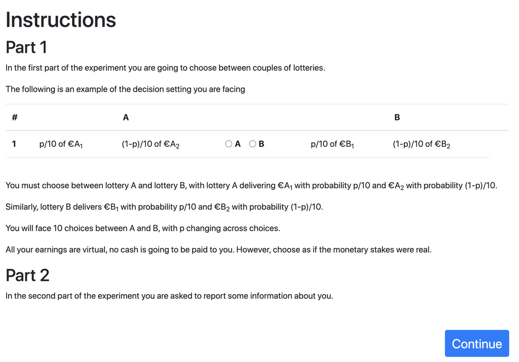

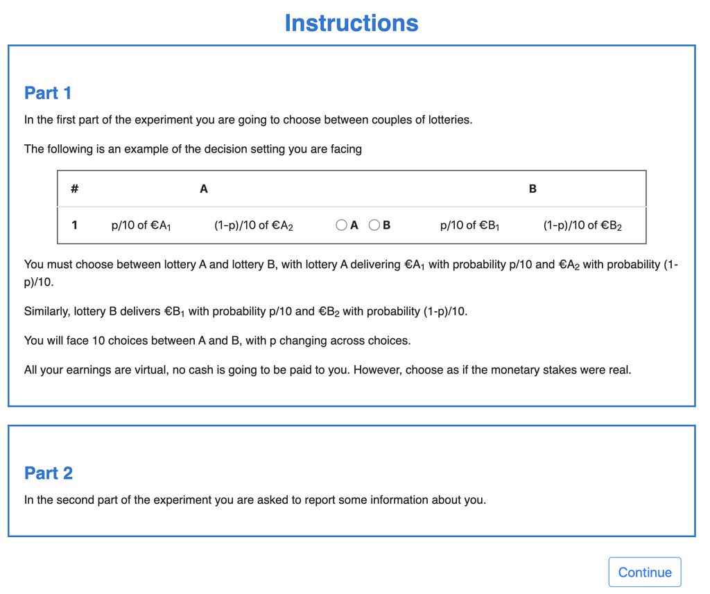

- To change the appearance we “apply” the following style changes in our `mystyle.css`

```css
.box {
    border-style: solid;
    border-color: #0275d8;
    padding-bottom: 20px;
    padding-left: 20px;
    padding-top: 10px;
    padding-right: 20px;
}

.table {
    width: 90%;
    border: 2px solid;
    text-align:center;
    border-color: #686868;
}


h1 {
    font-family: 'Roboto Condensed', sans-serif;
    font-size: 24pt;
    font-weight: bold;
    color: #0275d8;
    text-align: center;
    width: 100%;
    margin: 0px 0 10px 0;
}

h2 {
    font-size: 18pt;
    font-family: 'Roboto Condensed', sans-serif;
    font-weight: bold;
    color: #0275d8;
    text-align: left;
    width: 100%;
    margin: 40px 0 10px 0;
}

p {
    font-family: 'Roboto Condensed', sans-serif;
    font-size: 12pt;
    line-height: 1.5em;
}

li {
    font-size: 12pt;
}

input[type=radio] {
    transform: scale(1.2);
    margin: 12px -10px 0px -30px;
}
```

## Example 2: funny and messy

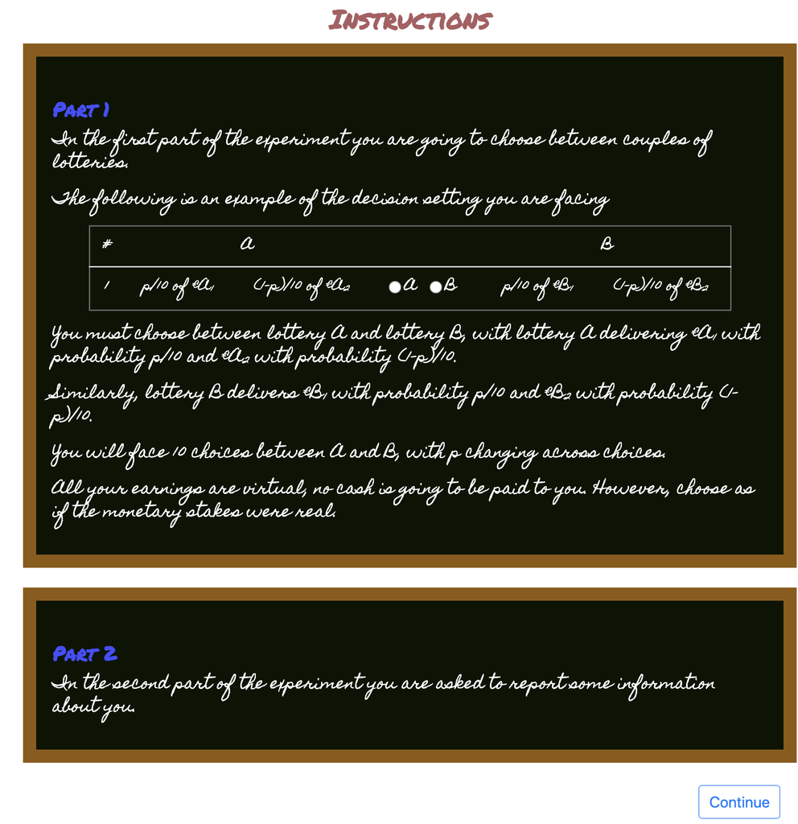

```css
.box {
    border-style: solid;
    border-color: #905b04;
    padding-bottom: 20px;
    padding-left: 20px;
    padding-top: 10px;
    padding-right: 20px;
    border-width:1em;
    background: rgb(11, 20, 3)
}

.table {
    width: 90%;
     font-family: 'Homemade Apple', cursive;
    border: 2px solid;
    text-align:center;
    border-color: #686868;
     color:white;
}

h1 {
    font-family: 'Permanent Marker', cursive;
    font-size: 24pt;
    font-weight: bold;
    color: #ad5d61;
    text-align: center;
    width: 100%;
    margin: 0px 0 10px 0;
}

h2 {
    font-size: 18pt;
    font-family: 'Permanent Marker', cursive;
    font-weight: bold;
    color: #4548fb;
    text-align: left;
    width: 100%;
    margin: 40px 0 10px 0;
}

p {
    font-family: 'Homemade Apple', cursive;
    font-size: 14pt;
    line-height: 1.5em;
    color:white;
}

li {
    font-family: 'Homemade Apple', cursive;
    font-size: 14pt;
     color:white;
}

input[type=radio] {
    transform: scale(1.2);
    margin: 12px -10px 0px -30px;
}
```

- In addition, to call special characters, insert

```html
{% block scripts %}
<link rel="preconnect" href="https://fonts.gstatic.com">
<link href="https://fonts.googleapis.com/css2?family=Homemade+Apple&family=Permanent+Marker&family=Sacramento&display=swap" rel="stylesheet">
{% endblock %}
```

## Icons

```html
<span class="iconify" data-icon="logos:css-3" data-inline="false" ></span>
<span class="iconify" data-icon="logos:html-5" data-inline="false"></span>
<span class="iconify" data-icon="logos:javascript" data-inline="false"></span>
```

- In the .html template then add

```html
{% block scripts %}
<script src="https://code.iconify.design/1/1.0.7/iconify.min.js"></script>
{% endblock %}
```

# Multilanguage

## Apps in different languages

- In many circumstances, you may want to have your app in different languages
  - Experimens in differen tcountries
  - Development with foreign colleagues
- Wrong solution
  - Write an app in each language
    - As an example, Italian, English, …
  - If you make changes you must change all your apps
    - Apps might not be fully consistent
- Right solution
  - Write your app in one reference language and then “translate” the templates
    - All changes are *centralized*

## Template

```html
{% extends "global/Page.html" %}
{% load otree i18n %} <!-- load this -->
{% load otree static %}

{% block title %}
    {% trans 'Page Title' %}
{% endblock %}

{% block content %}

{% trans 'Here we translate' %}

    {% next_button %}

{% endblock %}
```

- Add `{% load otree i18n %}` in the opening of your page
- The text to be translated must be within the tag {% trans ‘TEXT TO BE TRANSLATED’ %}
  - Here, we transalte from English to Italian

## Commands

- 1. In your app main folder create a subfolder named `locale`
- 2. In the app main folder run the command

  > django-admin makemessages -l it
  - The letters after -l identify the *destination language* (here Italian)
- 3. In subfolder ‘locale’ there is a file `django.po` that can be edited with the translation

## File django.po

```html
# SOME DESCRIPTIVE TITLE.
# Copyright (C) YEAR THE PACKAGE'S COPYRIGHT HOLDER
# This file is distributed under the same license as the PACKAGE package.
# FIRST AUTHOR <EMAIL@ADDRESS>, YEAR.
#
#, fuzzy
msgid ""
msgstr ""
"Project-Id-Version: PACKAGE VERSION\n"
"Report-Msgid-Bugs-To: \n"
"POT-Creation-Date: 2020-11-26 21:32+0100\n"
"PO-Revision-Date: YEAR-MO-DA HO:MI+ZONE\n"
"Last-Translator: FULL NAME <EMAIL@ADDRESS>\n"
"Language-Team: LANGUAGE <LL@li.org>\n"
"Language: \n"
"MIME-Version: 1.0\n"
"Content-Type: text/plain; charset=UTF-8\n"
"Content-Transfer-Encoding: 8bit\n"
"Plural-Forms: nplurals=2; plural=(n != 1);\n"

#: templates/language/MyPage.html:6
msgid "Page Title"
msgstr ""

#: templates/language/MyPage.html:11
msgid "Here we translate"
msgstr ""
```

- At each `msgstr " "` we insert the Italian translation
  - As an example,
    - for `msgid "Page Title"` we write `msgstr "Titolo"`
    - for `msgid "Here we translate"` we write `msgstr "Qui traduciamo"`
- After we translate everything, we give the command from the app main folder

> django-admin compilemessages
- This creates the file `django.mo`
  - This command must be run every time you add a translation
- To run the italian version change the language code in `settings.py`
  - `LANGUAGE_CODE = 'it'` (*en* for English)

# Dynamic graphs

## Responsive graphs

- It is possible to draw dynamic responsive graphs (see PGG)
  - We rely on Highcharts library under a Creative Commons Attribution-NonCommercial 3.0

[interactive chart not shown]

## Code

- In subfolder `static/name_of_app` we insert
  - The JavaScript file `hihcharts.js`
    - Library needed to create the graph
  - The JavaScript file `miografico.js`
    - Contains a function to draw the graph

[interactive chart not shown]

- In the template the graph is “inserted” with
  - `id=graph` should match `$('#graph').highcharts({ ...`

```html
     <div class="col-sm-6">
         <div id="graph" style="width:100%; height:300px;"> </div>
     </div>
```

```javascript
function draw_graph(history_contrib,round_number){
  $('#graph').highcharts({
      chart: {
          type: 'line'
      },
      title: {
          text: 'Total earnings from the project'
      },
      xAxis: {
        allowDecimals: false,
         accessibility: {
            rangeDescription: 'Range: 1 to 10'
        }
      },
      yAxis: {
          title: {
              text: 'Points'
          }
      },
        plotOptions: {
        series: {
            label: {
                connectorAllowed: false
            },
            pointStart: 1
        }
    },
      series: [{
          name: 'Total earnings',
          color: '#79dcb4',
          data: history_contrib
      }]
  });
}
```

# Live pages

## Continuous time

- **Live pages** allow to send data in continuous time
  - This module is needed for markets or “live” communication
- Javascript is needed to take care of communication between server and clients
  - In the JavaScript code of the template insert function `liveSend()` to send data to the server.
- In `models.py` in the `class Player` define a method to receive the message

```python
class Player(BasePlayer):

    def live_message(self, data):
        print('received a message from', self.id_in_group, ':', data)
```

- The name of the method should start with `live_`
- In you Page set `live_method` to route messages to that method

```python
- class MyPage(Page):
    live_method = 'live_message'
```

## Example: submit a random number in real time

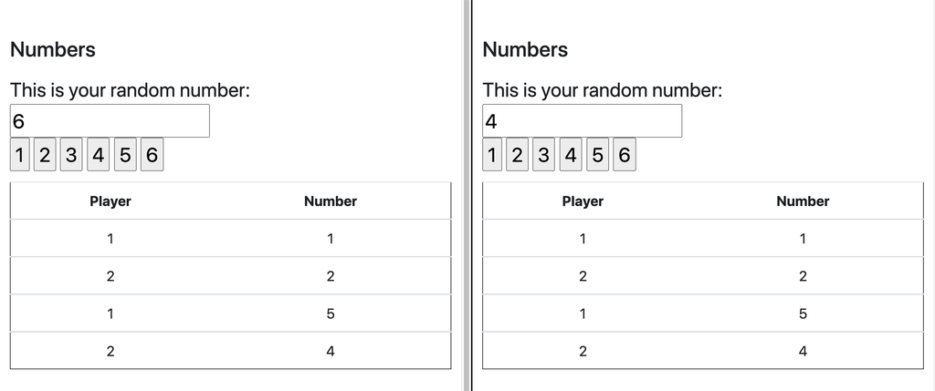

## Template: HTML Code

- In you HTML
  - A series of buttons to collect the value

```html
<input class="mybutton" type="button" id="input_1" name="input" value="1">
<input class="mybutton" type="button" id="input_2" name="input" value="2">
<input class="mybutton" type="button" id="input_3" name="input" value="3">
<input class="mybutton" type="button" id="input_4" name="input" value="4">
<input class="mybutton" type="button" id="input_5" name="input" value="5">
<input class="mybutton" type="button" id="input_6" name="input" value="6">
```

- A table with id `history` to show historical values

```html
<table id="history" class="table">
    <tr>
        <th>Player</th>
        <th>Number</th>
    </tr>
</table>
```

## Template: Javascript Code

```html
{% block scripts %}

<script>

//send values
 $('.mybutton').click(function(){
     liveSend($('#' + this.id).val());
 });

// to "store" data in a table
    let history = document.getElementById('history');

    function liveRecv(data) {
        history.innerHTML += '<tr><td>' + data.id_in_group + '</td><td>' + data.disp_value + '</td></tr>';
    }
</script>

{% endblock %}
```

- `liveSend` to send data to the server
  - Collect the value by `id`
- `let history = document.getElementById('history');`
  - Returns the element that has the ID attribute
    - Collect data in the dynamic table with `id=history`
- `liveRecv`
  - Called each time a message is received from the server
    - Writes a new line in table history
      - Values are obtained from the method defined in models.py

## models.py and pages.py

```python
class Player(BasePlayer):
    def live_broadcast(self, value):
        group = self.group
        my_id = self.id_in_group
        response = dict(id_in_group=my_id, disp_value=value)
        return {0: response}
```

- A method to receive the message from the server
  - Values are stored in a dictionary
    - Values are passed to function `liveRecv()`
- In `pages.py` insert the live method

```python
live_method = 'live_broadcast'
```

# Appendix

## OTree code

- Styles

Download styles.zip

- Live Pages

Download live_pages.zip